# First Pass: Walmart_Sales.csv

**Run Timestamp:** 2026-10-04 16:41:43 **First Pass Version:** 1.1.0

## Input Summary

- **File:** C:\Users\arvin\Desktop\Sample Datasets\Walmart_Sales.csv
- **Shape:** 6435 rows, 8 columns

## Raw Data Profile

```python
%matplotlib inline
import pandas as pd
import matplotlib.pyplot as plt
import seaborn as sns
import warnings
warnings.filterwarnings('ignore')
sns.set_theme(style='whitegrid', palette='deep')
from IPython.display import display
from first_pass.ingest import load_spreadsheet
df = load_spreadsheet('C:/Users/arvin/Desktop/Sample Datasets/Walmart_Sales.csv')
display(df.head())
df.info()
```

|  | Store | Date | Weekly_Sales | Holiday_Flag | Temperature | Fuel_Price | CPI | Unemployment |
| --- | --- | --- | --- | --- | --- | --- | --- | --- |
| 0 | 1 | 05-02-2010 | 1643690.90 | 0 | 42.31 | 2.572 | 211.096358 | 8.106 |
| 1 | 1 | 12-02-2010 | 1641957.44 | 1 | 38.51 | 2.548 | 211.242170 | 8.106 |
| 2 | 1 | 19-02-2010 | 1611968.17 | 0 | 39.93 | 2.514 | 211.289143 | 8.106 |
| 3 | 1 | 26-02-2010 | 1409727.59 | 0 | 46.63 | 2.561 | 211.319643 | 8.106 |
| 4 | 1 | 05-03-2010 | 1554806.68 | 0 | 46.50 | 2.625 | 211.350143 | 8.106 |

```
<class 'pandas.core.frame.DataFrame'>
RangeIndex: 6435 entries, 0 to 6434
Data columns (total 8 columns):
 #   Column        Non-Null Count  Dtype
---  ------        --------------  -----
 0   Store         6435 non-null   int64
 1   Date          6435 non-null   object
 2   Weekly_Sales  6435 non-null   float64
 3   Holiday_Flag  6435 non-null   int64
 4   Temperature   6435 non-null   float64
 5   Fuel_Price    6435 non-null   float64
 6   CPI           6435 non-null   float64
 7   Unemployment  6435 non-null   float64
dtypes: float64(5), int64(2), object(1)
memory usage: 402.3+ KB
```

## Cleaning Plan

No cleaning steps planned.

## Cleaned Data Profile

```python
display(df.head())
df.info()
```

|  | Store | Date | Weekly_Sales | Holiday_Flag | Temperature | Fuel_Price | CPI | Unemployment |
| --- | --- | --- | --- | --- | --- | --- | --- | --- |
| 0 | 1 | 05-02-2010 | 1643690.90 | 0 | 42.31 | 2.572 | 211.096358 | 8.106 |
| 1 | 1 | 12-02-2010 | 1641957.44 | 1 | 38.51 | 2.548 | 211.242170 | 8.106 |
| 2 | 1 | 19-02-2010 | 1611968.17 | 0 | 39.93 | 2.514 | 211.289143 | 8.106 |
| 3 | 1 | 26-02-2010 | 1409727.59 | 0 | 46.63 | 2.561 | 211.319643 | 8.106 |
| 4 | 1 | 05-03-2010 | 1554806.68 | 0 | 46.50 | 2.625 | 211.350143 | 8.106 |

```
<class 'pandas.core.frame.DataFrame'>
RangeIndex: 6435 entries, 0 to 6434
Data columns (total 8 columns):
 #   Column        Non-Null Count  Dtype
---  ------        --------------  -----
 0   Store         6435 non-null   int64
 1   Date          6435 non-null   object
 2   Weekly_Sales  6435 non-null   float64
 3   Holiday_Flag  6435 non-null   int64
 4   Temperature   6435 non-null   float64
 5   Fuel_Price    6435 non-null   float64
 6   CPI           6435 non-null   float64
 7   Unemployment  6435 non-null   float64
dtypes: float64(5), int64(2), object(1)
memory usage: 402.3+ KB
```

## Export Cleaned Data

```python
try:
    df.to_csv('temp/Walmart_Sales_Validation_cleaned.csv', index=False)
    df.to_excel('temp/Walmart_Sales_Validation_cleaned.xlsx', index=False)
    df.to_parquet('temp/Walmart_Sales_Validation_cleaned.parquet', index=False)
    # Manual xls export since pandas dropped it
    import xlwt
    wb = xlwt.Workbook()
    ws = wb.add_sheet('Sheet1')
    import csv
    with open('temp/Walmart_Sales_Validation_cleaned.csv', 'r', encoding='utf-8') as f:
        for r, row in enumerate(csv.reader(f)):
            for c, val in enumerate(row):
                ws.write(r, c, val)
    wb.save('temp/Walmart_Sales_Validation_cleaned.xls')
except Exception as e:
    print(f'Error saving dataset: {e}')
```

## Analysis Plan

**Target Variables:** Weekly_Sales

### Section 1: Data Overview

High-level summary of data types, summary statistics, and missing values.

| Step | Columns | Template | Rationale | Playbooks |
| --- | --- | --- | --- | --- |
| 1 |  | `column_overview` | Overview of column types and missing values. |  |
| 2 |  | `summary_stats` | High-level summary statistics of all columns. |  |

### Section 2: Store Revenue Benchmarking: Disparities and Tiered Performance

Evaluate historical sales distribution across the 45 store locations to identify top revenue generators, systemic underperformers, and operational variance across the network.

| Step | Columns | Template | Rationale | Playbooks |
| --- | --- | --- | --- | --- |
| 1 | Store, Weekly_Sales | `custom_code` | Identifies store tiering, pinpointing top-tier retail assets versus laggards requiring operational intervention. | custom_code |
| 2 | Weekly_Sales | `custom_code` | Quantifies positive skew in sales distributions to verify whether revenue concentration is driven by elite outlier stores. | custom_code |

### Section 3: Seasonality & Holiday Catalysts: Evaluating Promotional Uplift

Isolate the incremental sales volume generated during strategic holiday weeks against baseline non-holiday periods across the store base.

| Step | Columns | Template | Rationale | Playbooks |
| --- | --- | --- | --- | --- |
| 1 | Holiday_Flag, Weekly_Sales | `custom_code` | Quantifies the margin expansion and top-line lift generated during designated promotional holiday weeks. | custom_code |
| 2 | Date, Weekly_Sales, Holiday_Flag | `custom_code` | Surfaces underlying annualized trends by smoothing high-frequency noise and contextualizing seasonal holiday peaks. | custom_code |

### Section 4: Macroeconomic Headwinds: Inflation, Fuel Prices, and Labor Pressures

Assess the sensitivity of retail consumer spending against macroeconomic shifts, including CPI inflation, unemployment levels, fuel costs, and ambient temperature.

| Step | Columns | Template | Rationale | Playbooks |
| --- | --- | --- | --- | --- |
| 1 | Weekly_Sales, Temperature, Fuel_Price, CPI, Unemployment | `custom_code` | Determines the directionality and linear magnitude of macroeconomic factors on consumer retail behavior. | custom_code |
| 2 | Weekly_Sales, Unemployment, CPI | `custom_code` | Clarifies elasticity of store demand in regions experiencing elevated unemployment and inflationary pressures. | custom_code |

## 1. Data Overview

High-level summary of data types, summary statistics, and missing values.

### Column Overview

Overview of column types and missing values.

```python
try:
    display(df.dtypes)
except Exception as e:
    print(f'\nError executing column_overview: {e}')
```

```
Store             int64
Date             object
Weekly_Sales    float64
Holiday_Flag      int64
Temperature     float64
Fuel_Price      float64
CPI             float64
Unemployment    float64
dtype: object
```

### Summary Statistics

High-level summary statistics of all columns.

```python
try:
    display(df.describe(include='all'))
except Exception as e:
    print(f'\nError executing summary_stats: {e}')
```

|  | Store | Date | Weekly_Sales | Holiday_Flag | Temperature | Fuel_Price | CPI | Unemployment |
| --- | --- | --- | --- | --- | --- | --- | --- | --- |
| count | 6435.000000 | 6435 | 6.435000e+03 | 6435.000000 | 6435.000000 | 6435.000000 | 6435.000000 | 6435.000000 |
| unique | NaN | 143 | NaN | NaN | NaN | NaN | NaN | NaN |
| top | NaN | 05-02-2010 | NaN | NaN | NaN | NaN | NaN | NaN |
| freq | NaN | 45 | NaN | NaN | NaN | NaN | NaN | NaN |
| mean | 23.000000 | NaN | 1.046965e+06 | 0.069930 | 60.663782 | 3.358607 | 171.578394 | 7.999151 |
| std | 12.988182 | NaN | 5.643666e+05 | 0.255049 | 18.444933 | 0.459020 | 39.356712 | 1.875885 |
| min | 1.000000 | NaN | 2.099862e+05 | 0.000000 | -2.060000 | 2.472000 | 126.064000 | 3.879000 |
| 25% | 12.000000 | NaN | 5.533501e+05 | 0.000000 | 47.460000 | 2.933000 | 131.735000 | 6.891000 |
| 50% | 23.000000 | NaN | 9.607460e+05 | 0.000000 | 62.670000 | 3.445000 | 182.616521 | 7.874000 |
| 75% | 34.000000 | NaN | 1.420159e+06 | 0.000000 | 74.940000 | 3.735000 | 212.743293 | 8.622000 |
| max | 45.000000 | NaN | 3.818686e+06 | 1.000000 | 100.140000 | 4.468000 | 227.232807 | 14.313000 |

## 2. Store Revenue Benchmarking: Disparities and Tiered Performance

Evaluate historical sales distribution across the 45 store locations to identify top revenue generators, systemic underperformers, and operational variance across the network.

### Which stores drive the highest total volume and show the widest performance variance?

Identifies store tiering, pinpointing top-tier retail assets versus laggards requiring operational intervention.

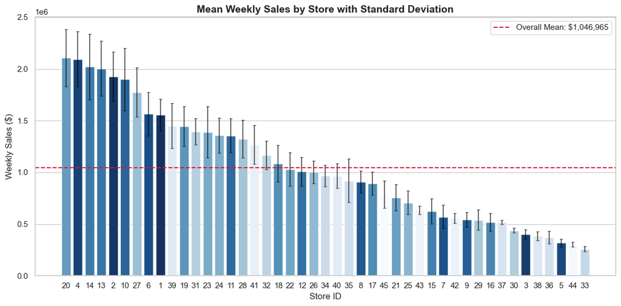

```python
try:
    store_perf = df.groupby('Store')['Weekly_Sales'].agg(['mean', 'std']).reset_index().sort_values(by='mean', ascending=False); fig, ax = plt.subplots(figsize=(12, 6)); sns.barplot(data=store_perf, x='Store', y='mean', order=store_perf['Store'], hue='Store', palette='Blues_r', legend=False, ax=ax); ax.errorbar(x=range(len(store_perf)), y=store_perf['mean'], yerr=store_perf['std'], fmt='none', c='black', capsize=2, alpha=0.6); ax.axhline(df['Weekly_Sales'].mean(), color='crimson', linestyle='--', label=f'Overall Mean: ${df["Weekly_Sales"].mean():,.0f}'); ax.set_title('Mean Weekly Sales by Store with Standard Deviation', fontsize=14, weight='bold'); ax.set_xlabel('Store ID'); ax.set_ylabel('Weekly Sales ($)'); ax.legend(); plt.tight_layout(); plt.show()
except Exception as e:
    print(f'\nError executing custom_code: {e}')
```

### How skewed is the overall weekly sales volume across the enterprise footprint?

Quantifies positive skew in sales distributions to verify whether revenue concentration is driven by elite outlier stores.

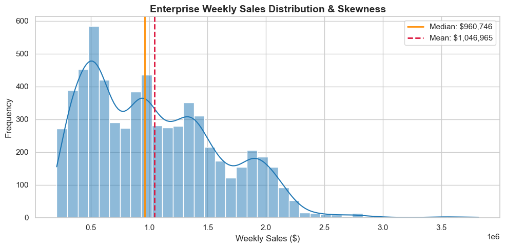

```python
try:
    fig, ax = plt.subplots(figsize=(10, 5)); sns.histplot(df['Weekly_Sales'], kde=True, color='#1f77b4', bins=40, ax=ax); median_val = df['Weekly_Sales'].median(); mean_val = df['Weekly_Sales'].mean(); ax.axvline(median_val, color='darkorange', linestyle='-', linewidth=2, label=f'Median: ${median_val:,.0f}'); ax.axvline(mean_val, color='crimson', linestyle='--', linewidth=2, label=f'Mean: ${mean_val:,.0f}'); ax.set_title('Enterprise Weekly Sales Distribution & Skewness', fontsize=14, weight='bold'); ax.set_xlabel('Weekly Sales ($)'); ax.set_ylabel('Frequency'); ax.legend(); plt.tight_layout(); plt.show()
except Exception as e:
    print(f'\nError executing custom_code: {e}')
```

**Insight:** The enterprise weekly sales distribution is moderately right-skewed, evidenced by the mean of approximately $1.05M sitting above the median of $961K. The multi-modal clustering under $1M reflects structural divergence between smaller format or low-volume locations and dominant flagship stores. Strategic forecasting models must account for this skewness by employing robust estimators or segment-level transformations rather than assuming normality.

## 3. Seasonality & Holiday Catalysts: Evaluating Promotional Uplift

Isolate the incremental sales volume generated during strategic holiday weeks against baseline non-holiday periods across the store base.

### Does the holiday calendar deliver statistically significant sales uplift across store tiers?

Quantifies the margin expansion and top-line lift generated during designated promotional holiday weeks.

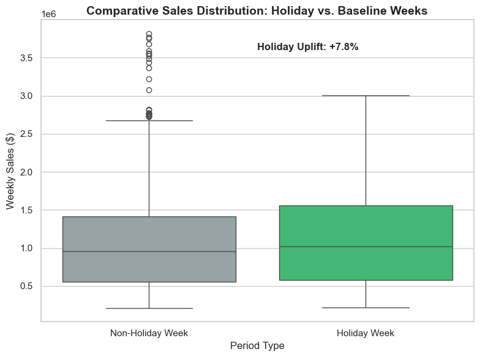

```python
try:
    fig, ax = plt.subplots(figsize=(8, 6)); sns.boxplot(data=df, x='Holiday_Flag', y='Weekly_Sales', hue='Holiday_Flag', palette=['#95a5a6', '#2ecc71'], legend=False, ax=ax); ax.set_xticklabels(['Non-Holiday Week', 'Holiday Week']); ax.set_title('Comparative Sales Distribution: Holiday vs. Baseline Weeks', fontsize=14, weight='bold'); ax.set_xlabel('Period Type'); ax.set_ylabel('Weekly Sales ($)'); uplift = (df[df['Holiday_Flag'] == 1]['Weekly_Sales'].mean() / df[df['Holiday_Flag'] == 0]['Weekly_Sales'].mean() - 1) * 100; ax.text(0.5, 0.9, f'Holiday Uplift: +{uplift:.1f}%', transform=ax.transAxes, fontsize=12, weight='bold', bbox=dict(facecolor='white', alpha=0.8)); plt.tight_layout(); plt.show()
except Exception as e:
    print(f'\nError executing custom_code: {e}')
```

### How does sales velocity trend across time with seasonal holiday spikes?

Surfaces underlying annualized trends by smoothing high-frequency noise and contextualizing seasonal holiday peaks.

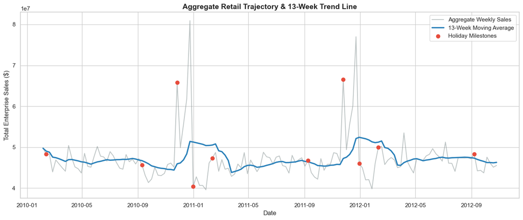

```python
try:
    df_time = df.copy(); df_time['Date'] = pd.to_datetime(df_time['Date'], format='%d-%m-%Y'); agg_time = df_time.groupby(['Date', 'Holiday_Flag'])['Weekly_Sales'].sum().reset_index().sort_values('Date'); agg_time['Rolling_13Wk'] = agg_time['Weekly_Sales'].rolling(window=13, min_periods=1).mean(); fig, ax = plt.subplots(figsize=(14, 6)); ax.plot(agg_time['Date'], agg_time['Weekly_Sales'], color='#7f8c8d', alpha=0.5, label='Aggregate Weekly Sales'); ax.plot(agg_time['Date'], agg_time['Rolling_13Wk'], color='#2980b9', linewidth=2.5, label='13-Week Moving Average'); holidays = agg_time[agg_time['Holiday_Flag'] == 1]; ax.scatter(holidays['Date'], holidays['Weekly_Sales'], color='#e74c3c', s=50, zorder=5, label='Holiday Milestones'); ax.set_title('Aggregate Retail Trajectory & 13-Week Trend Line', fontsize=14, weight='bold'); ax.set_xlabel('Date'); ax.set_ylabel('Total Enterprise Sales ($)'); ax.legend(); plt.tight_layout(); plt.show()
except Exception as e:
    print(f'\nError executing custom_code: {e}')
```

**Insight:** The longitudinal trajectory displays recurring end-of-year spikes exceeding $75M–$80M in aggregate sales around November and December, followed by predictable post-holiday pullbacks in January. Beyond these sharp Q4 surges, the 13-week moving average demonstrates stable, resilient core performance hovering between $45M and $50M throughout the year. Retail leadership can leverage this predictable cyclicality to optimize procurement lead times and smooth warehouse throughput ahead of annual demand surges.

## 4. Macroeconomic Headwinds: Inflation, Fuel Prices, and Labor Pressures

Assess the sensitivity of retail consumer spending against macroeconomic shifts, including CPI inflation, unemployment levels, fuel costs, and ambient temperature.

### What is the structural correlation between external macroeconomic variables and store revenue?

Determines the directionality and linear magnitude of macroeconomic factors on consumer retail behavior.

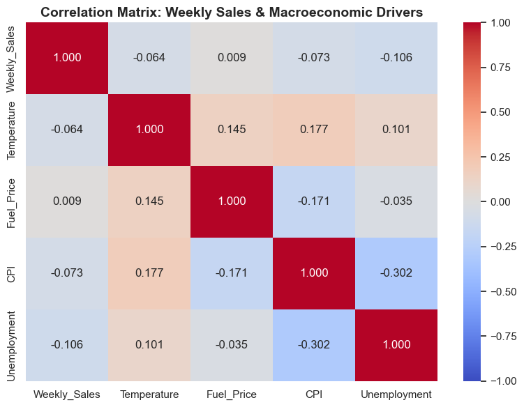

```python
try:
    corr_cols = ['Weekly_Sales', 'Temperature', 'Fuel_Price', 'CPI', 'Unemployment']; corr_matrix = df[corr_cols].corr(); fig, ax = plt.subplots(figsize=(8, 6)); sns.heatmap(corr_matrix, annot=True, fmt='.3f', cmap='coolwarm', vmin=-1, vmax=1, ax=ax); ax.set_title('Correlation Matrix: Weekly Sales & Macroeconomic Drivers', fontsize=14, weight='bold'); plt.tight_layout(); plt.show()
except Exception as e:
    print(f'\nError executing custom_code: {e}')
```

**Insight:** The correlation matrix reveals surprisingly weak linear relationships between weekly sales and external macroeconomic indicators, with unemployment showing the strongest (yet still marginal) inverse correlation (-0.106). This indicates that weekly revenue performance is largely insulated from short-term fluctuations in fuel prices, general inflation (CPI), or temperature changes at the enterprise level. Consequently, business planning and demand forecasting should focus more on internal operational levers, local store footprint, and promotional scheduling rather than macro trends alone.

### Does high regional unemployment or inflation exert downward pressure on store sales?

Clarifies elasticity of store demand in regions experiencing elevated unemployment and inflationary pressures.

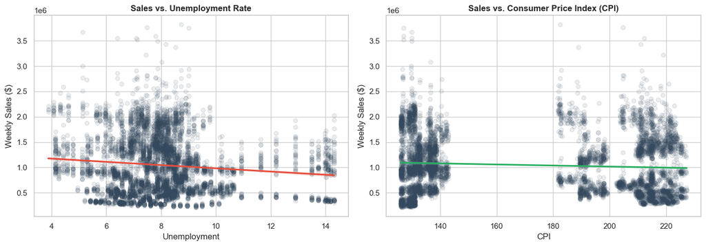

```python
try:
    fig, (ax1, ax2) = plt.subplots(1, 2, figsize=(14, 5)); sns.regplot(data=df, x='Unemployment', y='Weekly_Sales', scatter_kws={'alpha':0.1, 'color':'#34495e'}, line_kws={'color':'#e74c3c'}, ax=ax1); ax1.set_title('Sales vs. Unemployment Rate', fontsize=12, weight='bold'); ax1.set_ylabel('Weekly Sales ($)'); sns.regplot(data=df, x='CPI', y='Weekly_Sales', scatter_kws={'alpha':0.1, 'color':'#34495e'}, line_kws={'color':'#27ae60'}, ax=ax2); ax2.set_title('Sales vs. Consumer Price Index (CPI)', fontsize=12, weight='bold'); ax2.set_ylabel('Weekly Sales ($)'); plt.tight_layout(); plt.show()
except Exception as e:
    print(f'\nError executing custom_code: {e}')
```

## Further Analyses to Consider

The following analyses were considered relevant but skipped to keep this first pass concise.

| Tool | Columns | Rationale |
| --- | --- | --- |
| `custom_code` | Store, Date, Weekly_Sales | Implement an autoregressive SARIMA or Prophet demand-forecasting model to project store-level weekly inventory requirements. |
| `custom_code` | Store, CPI, Unemployment, Weekly_Sales | Perform k-means cluster analysis on store locations based on macroeconomic exposure to design localized commercial pricing strategies. |

## Appendix

### Raw Cleaning Plan JSON

```
{
  "steps": []
}
```

### Raw Analysis Plan JSON

```
{
  "target_variables": [
    "Weekly_Sales"
  ],
  "sections": [
    {
      "title": "Data Overview",
      "description": "High-level summary of data types, summary statistics, and missing values.",
      "analyses": [
        {
          "title": "Column Overview",
          "template_id": "column_overview",
          "columns": [],
          "params": "{}",
          "rationale": "Overview of column types and missing values.",
          "playbook_ids": []
        },
        {
          "title": "Summary Statistics",
          "template_id": "summary_stats",
          "columns": [],
          "params": "{}",
          "rationale": "High-level summary statistics of all columns.",
          "playbook_ids": []
        }
      ]
    },
    {
      "title": "Store Revenue Benchmarking: Disparities and Tiered Performance",
      "description": "Evaluate historical sales distribution across the 45 store locations to identify top revenue generators, systemic underperformers, and operational variance across the network.",
      "analyses": [
        {
          "title": "Which stores drive the highest total volume and show the widest performance variance?",
          "template_id": "custom_code",
          "columns": [
            "Store",
            "Weekly_Sales"
          ],
          "params": "{\"code_snippet\": \"store_perf = df.groupby('Store')['Weekly_Sales'].agg(['mean', 'std']).reset_index().sort_values(by='mean', ascending=False); fig, ax = plt.subplots(figsize=(12, 6)); sns.barplot(data=store_perf, x='Store', y='mean', order=store_perf['Store'], hue='Store', palette='Blues_r', legend=False, ax=ax); ax.errorbar(x=range(len(store_perf)), y=store_perf['mean'], yerr=store_perf['std'], fmt='none', c='black', capsize=2, alpha=0.6); ax.axhline(df['Weekly_Sales'].mean(), color='crimson', linestyle='--', label=f'Overall Mean: ${df[\\\"Weekly_Sales\\\"].mean():,.0f}'); ax.set_title('Mean Weekly Sales by Store with Standard Deviation', fontsize=14, weight='bold'); ax.set_xlabel('Store ID'); ax.set_ylabel('Weekly Sales ($)'); ax.legend(); plt.tight_layout(); plt.show()\"}",
          "rationale": "Identifies store tiering, pinpointing top-tier retail assets versus laggards requiring operational intervention.",
          "playbook_ids": [
            "custom_code"
          ]
        },
        {
          "title": "How skewed is the overall weekly sales volume across the enterprise footprint?",
          "template_id": "custom_code",
          "columns": [
            "Weekly_Sales"
          ],
          "params": "{\"code_snippet\": \"fig, ax = plt.subplots(figsize=(10, 5)); sns.histplot(df['Weekly_Sales'], kde=True, color='#1f77b4', bins=40, ax=ax); median_val = df['Weekly_Sales'].median(); mean_val = df['Weekly_Sales'].mean(); ax.axvline(median_val, color='darkorange', linestyle='-', linewidth=2, label=f'Median: ${median_val:,.0f}'); ax.axvline(mean_val, color='crimson', linestyle='--', linewidth=2, label=f'Mean: ${mean_val:,.0f}'); ax.set_title('Enterprise Weekly Sales Distribution & Skewness', fontsize=14, weight='bold'); ax.set_xlabel('Weekly Sales ($)'); ax.set_ylabel('Frequency'); ax.legend(); plt.tight_layout(); plt.show()\"}",
          "rationale": "Quantifies positive skew in sales distributions to verify whether revenue concentration is driven by elite outlier stores.",
          "playbook_ids": [
            "custom_code"
          ]
        }
      ]
    },
    {
      "title": "Seasonality & Holiday Catalysts: Evaluating Promotional Uplift",
      "description": "Isolate the incremental sales volume generated during strategic holiday weeks against baseline non-holiday periods across the store base.",
      "analyses": [
        {
          "title": "Does the holiday calendar deliver statistically significant sales uplift across store tiers?",
          "template_id": "custom_code",
          "columns": [
            "Holiday_Flag",
            "Weekly_Sales"
          ],
          "params": "{\"code_snippet\": \"fig, ax = plt.subplots(figsize=(8, 6)); sns.boxplot(data=df, x='Holiday_Flag', y='Weekly_Sales', hue='Holiday_Flag', palette=['#95a5a6', '#2ecc71'], legend=False, ax=ax); ax.set_xticklabels(['Non-Holiday Week', 'Holiday Week']); ax.set_title('Comparative Sales Distribution: Holiday vs. Baseline Weeks', fontsize=14, weight='bold'); ax.set_xlabel('Period Type'); ax.set_ylabel('Weekly Sales ($)'); uplift = (df[df['Holiday_Flag'] == 1]['Weekly_Sales'].mean() / df[df['Holiday_Flag'] == 0]['Weekly_Sales'].mean() - 1) * 100; ax.text(0.5, 0.9, f'Holiday Uplift: +{uplift:.1f}%', transform=ax.transAxes, fontsize=12, weight='bold', bbox=dict(facecolor='white', alpha=0.8)); plt.tight_layout(); plt.show()\"}",
          "rationale": "Quantifies the margin expansion and top-line lift generated during designated promotional holiday weeks.",
          "playbook_ids": [
            "custom_code"
          ]
        },
        {
          "title": "How does sales velocity trend across time with seasonal holiday spikes?",
          "template_id": "custom_code",
          "columns": [
            "Date",
            "Weekly_Sales",
            "Holiday_Flag"
          ],
          "params": "{\"code_snippet\": \"df_time = df.copy(); df_time['Date'] = pd.to_datetime(df_time['Date'], format='%d-%m-%Y'); agg_time = df_time.groupby(['Date', 'Holiday_Flag'])['Weekly_Sales'].sum().reset_index().sort_values('Date'); agg_time['Rolling_13Wk'] = agg_time['Weekly_Sales'].rolling(window=13, min_periods=1).mean(); fig, ax = plt.subplots(figsize=(14, 6)); ax.plot(agg_time['Date'], agg_time['Weekly_Sales'], color='#7f8c8d', alpha=0.5, label='Aggregate Weekly Sales'); ax.plot(agg_time['Date'], agg_time['Rolling_13Wk'], color='#2980b9', linewidth=2.5, label='13-Week Moving Average'); holidays = agg_time[agg_time['Holiday_Flag'] == 1]; ax.scatter(holidays['Date'], holidays['Weekly_Sales'], color='#e74c3c', s=50, zorder=5, label='Holiday Milestones'); ax.set_title('Aggregate Retail Trajectory & 13-Week Trend Line', fontsize=14, weight='bold'); ax.set_xlabel('Date'); ax.set_ylabel('Total Enterprise Sales ($)'); ax.legend(); plt.tight_layout(); plt.show()\"}",
          "rationale": "Surfaces underlying annualized trends by smoothing high-frequency noise and contextualizing seasonal holiday peaks.",
          "playbook_ids": [
            "custom_code"
          ]
        }
      ]
    },
    {
      "title": "Macroeconomic Headwinds: Inflation, Fuel Prices, and Labor Pressures",
      "description": "Assess the sensitivity of retail consumer spending against macroeconomic shifts, including CPI inflation, unemployment levels, fuel costs, and ambient temperature.",
      "analyses": [
        {
          "title": "What is the structural correlation between external macroeconomic variables and store revenue?",
          "template_id": "custom_code",
          "columns": [
            "Weekly_Sales",
            "Temperature",
            "Fuel_Price",
            "CPI",
            "Unemployment"
          ],
          "params": "{\"code_snippet\": \"corr_cols = ['Weekly_Sales', 'Temperature', 'Fuel_Price', 'CPI', 'Unemployment']; corr_matrix = df[corr_cols].corr(); fig, ax = plt.subplots(figsize=(8, 6)); sns.heatmap(corr_matrix, annot=True, fmt='.3f', cmap='coolwarm', vmin=-1, vmax=1, ax=ax); ax.set_title('Correlation Matrix: Weekly Sales & Macroeconomic Drivers', fontsize=14, weight='bold'); plt.tight_layout(); plt.show()\"}",
          "rationale": "Determines the directionality and linear magnitude of macroeconomic factors on consumer retail behavior.",
          "playbook_ids": [
            "custom_code"
          ]
        },
        {
          "title": "Does high regional unemployment or inflation exert downward pressure on store sales?",
          "template_id": "custom_code",
          "columns": [
            "Weekly_Sales",
            "Unemployment",
            "CPI"
          ],
          "params": "{\"code_snippet\": \"fig, (ax1, ax2) = plt.subplots(1, 2, figsize=(14, 5)); sns.regplot(data=df, x='Unemployment', y='Weekly_Sales', scatter_kws={'alpha':0.1, 'color':'#34495e'}, line_kws={'color':'#e74c3c'}, ax=ax1); ax1.set_title('Sales vs. Unemployment Rate', fontsize=12, weight='bold'); ax1.set_ylabel('Weekly Sales ($)'); sns.regplot(data=df, x='CPI', y='Weekly_Sales', scatter_kws={'alpha':0.1, 'color':'#34495e'}, line_kws={'color':'#27ae60'}, ax=ax2); ax2.set_title('Sales vs. Consumer Price Index (CPI)', fontsize=12, weight='bold'); ax2.set_ylabel('Weekly Sales ($)'); plt.tight_layout(); plt.show()\"}",
          "rationale": "Clarifies elasticity of store demand in regions experiencing elevated unemployment and inflationary pressures.",
          "playbook_ids": [
            "custom_code"
          ]
        }
      ]
    }
  ],
  "further_analyses": [
    {
      "template_id": "custom_code",
      "columns": [
        "Store",
        "Date",
        "Weekly_Sales"
      ],
      "rationale": "Implement an autoregressive SARIMA or Prophet demand-forecasting model to project store-level weekly inventory requirements."
    },
    {
      "template_id": "custom_code",
      "columns": [
        "Store",
        "CPI",
        "Unemployment",
        "Weekly_Sales"
      ],
      "rationale": "Perform k-means cluster analysis on store locations based on macroeconomic exposure to design localized commercial pricing strategies."
    }
  ]
}
```